# Model Tuning Project: ReneWind

### Defining scorer to be used for cross-validation and hyperparameter tuning

- To maximize profits, we can use the F1 score as the **scorer** in cross-validation and hyperparameter tuning.

```python
# Type of scoring used to compare parameter combinations
scorer = metrics.make_scorer(metrics.f1_score)
```

### Model Building with original data

```python
%%time

models = []  # Empty list to store all the models

# Appending models into the list
models.append(("dtree", DecisionTreeClassifier(random_state=1)))
models.append(("Bagging", BaggingClassifier(random_state=1)))
models.append(("Random forest", RandomForestClassifier(random_state=1)))
models.append(("GBM", GradientBoostingClassifier(random_state=1)))
models.append(("Adaboost", AdaBoostClassifier(random_state=1)))
models.append(("Xgboost", XGBClassifier(random_state=1, eval_metric="logloss")))

results1 = []  # Empty list to store all model's CV scores
names = []  # Empty list to store name of the models


# loop through all models to get the mean cross validated score
print("\n" "Cross-Validation Cost:" "\n")

for name, model in models:
    kfold = StratifiedKFold(
        n_splits=3, shuffle=True, random_state=1
    )  # Setting number of splits equal to 3
    cv_result = cross_val_score(
        estimator=model, X=X_train, y=y_train, scoring=scorer, cv=kfold
    )
    results1.append(cv_result)
    names.append(name)
    print("{}: {}".format(name, cv_result.mean()))

print("\n" "Validation Performance:" "\n")

for name, model in models:
    model.fit(X_train, y_train)
    scores = f1_score(y_val, model.predict(X_val))
    print("{}: {}".format(name, scores))
```

```
Cross-Validation Cost:

dtree: 0.7218217092576786
Bagging: 0.8197787111724587
Random forest: 0.8580420460119708
GBM: 0.8117295409358608
Adaboost: 0.7125194215509792
Xgboost: 0.8900910009642072

Validation Performance:

dtree: 0.7376014427412083
Bagging: 0.833160621761658
Random forest: 0.8639175257731959
GBM: 0.8171368861024034
Adaboost: 0.7126193001060445
Xgboost: 0.899502487562189
Wall time: 5min 1s
```

### Model Building with Oversampled data

```python
print("Before Oversampling, counts of label 'Yes': {}".format(sum(y_train == 1)))
print("Before Oversampling, counts of label 'No': {} \n".format(sum(y_train == 0)))

# Synthetic Minority Over Sampling Technique
sm = SMOTE(sampling_strategy=1, k_neighbors=5, random_state=1)
X_train_over, y_train_over = sm.fit_resample(X_train, y_train)

print("After Oversampling, counts of label 'Yes': {}".format(sum(y_train_over == 1)))
print("After Oversampling, counts of label 'No': {} \n".format(sum(y_train_over == 0)))

print("After Oversampling, the shape of X_train: {}".format(X_train_over.shape))
print("After Oversampling, the shape of y_train: {} \n".format(y_train_over.shape))
```

```
Before Oversampling, counts of label 'Yes': 1640
Before Oversampling, counts of label 'No': 28360

After Oversampling, counts of label 'Yes': 28360
After Oversampling, counts of label 'No': 28360

After Oversampling, the shape of X_train: (56720, 40)
After Oversampling, the shape of y_train: (56720,)
```

```python
%%time

models_over = []  # Empty list to store all the models

# Appending models into the list
models_over.append(("dtree", DecisionTreeClassifier(random_state=1)))
models_over.append(("Bagging", BaggingClassifier(random_state=1)))
models_over.append(("Random forest", RandomForestClassifier(random_state=1)))
models_over.append(("GBM", GradientBoostingClassifier(random_state=1)))
models_over.append(("Adaboost", AdaBoostClassifier(random_state=1)))
models_over.append(("Xgboost", XGBClassifier(random_state=1, eval_metric="logloss")))

results1_over = []  # Empty list to store all model's CV scores
names_over = []  # Empty list to store name of the models


# loop through all models to get the mean cross validated score
print("\n" "Cross-Validation Cost:" "\n")

for name, model in models_over:
    kfold = StratifiedKFold(
        n_splits=3, shuffle=True, random_state=1
    )  # Setting number of splits equal to 3
    cv_result = cross_val_score(
        estimator=model, X=X_train_over, y=y_train_over, scoring=scorer, cv=kfold
    )
    results1_over.append(cv_result)
    names_over.append(name)
    print("{}: {}".format(name, cv_result.mean()))

print("\n" "Validation Performance:" "\n")

for name, model in models_over:
    model.fit(X_train_over, y_train_over)
    scores = f1_score(y_val, model.predict(X_val))
    print("{}: {}".format(name, scores))
```

```
Cross-Validation Cost:

dtree: 0.9578354942551345
Bagging: 0.9796433419055214
Random forest: 0.9869614424330752
GBM: 0.9394911904324394
Adaboost: 0.9034014211576643
Xgboost: 0.9868417028739912

Validation Performance:

dtree: 0.6453952139231328
Bagging: 0.8502325581395348
Random forest: 0.9125840537944284
GBM: 0.7386973180076628
Adaboost: 0.4957356076759062
Xgboost: 0.8948837209302325
Wall time: 8min 1s
```

### Model Building with Undersampled data

```python
# Random undersampler for under sampling the data
rus = RandomUnderSampler(random_state=1, sampling_strategy=1)
X_train_under, y_train_under = rus.fit_resample(X_train, y_train)

print("Before Undersampling, counts of label 'Yes': {}".format(sum(y_train == 1)))
print("Before Undersampling, counts of label 'No': {} \n".format(sum(y_train == 0)))

print("After Undersampling, counts of label 'Yes': {}".format(sum(y_train_under == 1)))
print("After Undersampling, counts of label 'No': {} \n".format(sum(y_train_under == 0)))

print("After Undersampling, the shape of X_train: {}".format(X_train_under.shape))
print("After Undersampling, the shape of y_train: {} \n".format(y_train_under.shape))
```

```
Before Undersampling, counts of label 'Yes': 1640
Before Undersampling, counts of label 'No': 28360

After Undersampling, counts of label 'Yes': 1640
After Undersampling, counts of label 'No': 1640

After Undersampling, the shape of X_train: (3280, 40)
After Undersampling, the shape of y_train: (3280,)
```

```python
%%time

models_under = []  # Empty list to store all the models

# Appending models into the list
models_under.append(("dtree", DecisionTreeClassifier(random_state=1)))
models_under.append(("Bagging", BaggingClassifier(random_state=1)))
models_under.append(("Random forest", RandomForestClassifier(random_state=1)))
models_under.append(("GBM", GradientBoostingClassifier(random_state=1)))
models_under.append(("Adaboost", AdaBoostClassifier(random_state=1)))
models_under.append(("Xgboost", XGBClassifier(random_state=1, eval_metric="logloss")))

results1_under = []  # Empty list to store all model's CV scores
names_under = []  # Empty list to store name of the models


# loop through all models to get the mean cross validated score
print("\n" "Cross-Validation Cost:" "\n")

for name, model in models_under:
    kfold = StratifiedKFold(
        n_splits=3, shuffle=True, random_state=1
    )  # Setting number of splits equal to 3
    cv_result = cross_val_score(
        estimator=model, X=X_train_under, y=y_train_under, scoring=scorer, cv=kfold
    )
    results1_under.append(cv_result)
    names_under.append(name)
    print("{}: {}".format(name, cv_result.mean()))

print("\n" "Validation Performance:" "\n")

for name, model in models_under:
    model.fit(X_train_under, y_train_under)
    scores = f1_score(y_val, model.predict(X_val))
    print("{}: {}".format(name, scores))
```

```
Cross-Validation Cost:

dtree: 0.8527970743102711
Bagging: 0.8994857125634979
Random forest: 0.9261199918073831
GBM: 0.9145955574284502
Adaboost: 0.8772101326618461
Xgboost: 0.9294929552422416

Validation Performance:

dtree: 0.4112725671510348
Bagging: 0.6560111188325226
Random forest: 0.7423312883435583
GBM: 0.6662097326936258
Adaboost: 0.44020474639367146
Xgboost: 0.7596302003081663
Wall time: 20.8 s
```

#### Observations

- The four best performing models on the validation dataset, ranked from highest to lowest F1 scores, are:
  - Random forest with oversampled data
  - Xgboost with the original data
  - Xgboost with the oversampled data
  - Random forest with the original data

## Hyperparameter Tuning

### Sample Parameter Grids

**For hyperparameter tuning, we can use the following grids, wherever required.**

- For Gradient Boosting:

param_grid = { "n_estimators": np.arange(100,150,25), "learning_rate": [0.2, 0.05, 1], "subsample":[0.5,0.7], "max_features":[0.5,0.7] }

- For Adaboost:

param_grid = { "n_estimators": [100, 150, 200], "learning_rate": [0.2, 0.05], "base_estimator": [DecisionTreeClassifier(max_depth=1, random_state=1), DecisionTreeClassifier(max_depth=2, random_state=1), DecisionTreeClassifier(max_depth=3, random_state=1), ] }

- For Bagging Classifier:

param_grid = { 'max_samples': [0.8,0.9,1], 'max_features': [0.7,0.8,0.9], 'n_estimators' : [30,50,70], }

- For Random Forest:

param_grid = { "n_estimators": [200,250,300], "min_samples_leaf": np.arange(1, 4), "max_features": [np.arange(0.3, 0.6, 0.1),'sqrt'], "max_samples": np.arange(0.4, 0.7, 0.1) }

- For Decision Trees:

param_grid = { 'max_depth': np.arange(2,6), 'min_samples_leaf': [1, 4, 7], 'max_leaf_nodes' : [10, 15], 'min_impurity_decrease': [0.0001,0.001] }

- For Logistic Regression:

param_grid = {'C': np.arange(0.1,1.1,0.1)}

- For XGBoost:

param_grid={ 'n_estimators': [150, 200, 250], 'scale_pos_weight': [5,10], 'learning_rate': [0.1,0.2], 'gamma': [0,3,5], 'subsample': [0.8,0.9] }

### Tuning Random forest with original data

```python
%%time

# defining model
rf = RandomForestClassifier(random_state=1)

# Parameter grid to pass in RandomSearchCV
param_grid = {
    "n_estimators": [200,250,300],
    "min_samples_leaf": np.arange(1, 4),
    "max_features": [np.arange(0.3, 0.6, 0.1),'sqrt'],
    "max_samples": np.arange(0.4, 0.7, 0.1)
}

#Calling RandomizedSearchCV
rf_tuned = RandomizedSearchCV(estimator=rf, param_distributions=param_grid,
                              n_iter=10, n_jobs = -1, scoring=scorer, cv=5, random_state=1)

#Fitting parameters in RandomizedSearchCV
rf_tuned.fit(X_train,y_train)

print("Best parameters are {} with CV score={}:" .format(rf_tuned.best_params_, rf_tuned.best_score_))
```

```
Best parameters are {'n_estimators': 300, 'min_samples_leaf': 1, 'max_samples': 0.6, 'max_features': 'sqrt'} with CV score=0.852989009291389:
Wall time: 6min 43s
```

```python
# Creating new pipeline with best parameters
rf_tuned = RandomForestClassifier(
    n_estimators=300,
    min_samples_leaf=1,
    max_samples=0.6,
    max_features='sqrt',
    random_state=1
)

# Fit the model on undersampled training data
rf_tuned.fit(X_train, y_train)
```

```
RandomForestClassifier(max_features='sqrt', max_samples=0.6, n_estimators=300,
                       random_state=1)
```

```python
# Calculating different metrics on train set
rf_grid_train = model_performance_classification_sklearn(
    rf_tuned, X_train, y_train
)
print("Training performance:")
rf_grid_train
```

```
Training performance:
```

|  | Accuracy | Recall | Precision | F1 |
| --- | --- | --- | --- | --- |
| 0 | 0.99 | 0.90 | 1.00 | 0.95 |

```python
# Calculating different metrics on validation set
rf_grid_val = model_performance_classification_sklearn(
    rf_tuned, X_val, y_val
)
print("Validation performance:")
rf_grid_val
```

```
Validation performance:
```

|  | Accuracy | Recall | Precision | F1 |
| --- | --- | --- | --- | --- |
| 0 | 0.99 | 0.75 | 0.99 | 0.85 |

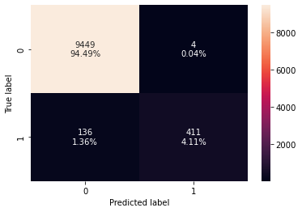

```python
# creating confusion matrix
confusion_matrix_sklearn(rf_tuned, X_val, y_val)
```

### Tuning Random forest with oversampled data

```python
%%time

# defining model
rf = RandomForestClassifier(random_state=1)

# Parameter grid to pass in RandomSearchCV
param_grid = {
    "n_estimators": [200,250,300],
    "min_samples_leaf": np.arange(1, 4),
    "max_features": [np.arange(0.3, 0.6, 0.1),'sqrt'],
    "max_samples": np.arange(0.4, 0.7, 0.1)
}

#Calling RandomizedSearchCV
rf_tuned_over = RandomizedSearchCV(estimator=rf, param_distributions=param_grid,
                              n_iter=10, n_jobs = -1, scoring=scorer, cv=5, random_state=1)

#Fitting parameters in RandomizedSearchCV
rf_tuned_over.fit(X_train_over,y_train_over)

print("Best parameters are {} with CV score={}:" .format(rf_tuned_over.best_params_, rf_tuned_over.best_score_))
```

```
Best parameters are {'n_estimators': 300, 'min_samples_leaf': 1, 'max_samples': 0.6, 'max_features': 'sqrt'} with CV score=0.9866763765986342:
Wall time: 10min 16s
```

```python
# Creating new pipeline with best parameters
rf_tuned_over = RandomForestClassifier(
    n_estimators=300,
    min_samples_leaf=1,
    max_samples=0.6,
    max_features='sqrt',
    random_state=1
)

# Fit the model on undersampled training data
rf_tuned_over.fit(X_train_over, y_train_over)
```

```
RandomForestClassifier(max_features='sqrt', max_samples=0.6, n_estimators=300,
                       random_state=1)
```

```python
# Calculating different metrics on train set
rf_grid_train_over = model_performance_classification_sklearn(
    rf_tuned_over, X_train_over, y_train_over
)
print("Training performance:")
rf_grid_train_over
```

```
Training performance:
```

|  | Accuracy | Recall | Precision | F1 |
| --- | --- | --- | --- | --- |
| 0 | 1.00 | 1.00 | 1.00 | 1.00 |

```python
# Calculating different metrics on validation set
rf_grid_val_over = model_performance_classification_sklearn(
    rf_tuned_over, X_val, y_val
)
print("Validation performance:")
rf_grid_val_over
```

```
Validation performance:
```

|  | Accuracy | Recall | Precision | F1 |
| --- | --- | --- | --- | --- |
| 0 | 0.99 | 0.87 | 0.95 | 0.91 |

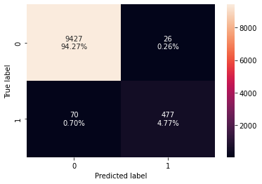

```python
# creating confusion matrix
confusion_matrix_sklearn(rf_tuned_over, X_val, y_val)
```

### Tuning Xgboost with original data

```python
%%time

# defining model
xb = XGBClassifier(random_state=1,eval_metric="logloss")

# Parameter grid to pass in RandomSearchCV
param_grid={
    'n_estimators': [150, 200, 250],
    'scale_pos_weight': [5,10],
    'learning_rate': [0.1,0.2],
    'gamma': [0,3,5],
    'subsample': [0.8,0.9]
}

#Calling RandomizedSearchCV
xb_tuned = RandomizedSearchCV(estimator=xb, param_distributions=param_grid, n_iter=10,
                              n_jobs = -1, scoring=scorer, cv=5, random_state=1)

#Fitting parameters in RandomizedSearchCV
xb_tuned.fit(X_train,y_train)

print("Best parameters are {} with CV score={}:" .format(xb_tuned.best_params_,xb_tuned.best_score_))
```

```
Best parameters are {'subsample': 0.9, 'scale_pos_weight': 10, 'n_estimators': 200, 'learning_rate': 0.2, 'gamma': 0} with CV score=0.9073849468844963:
Wall time: 13min 56s
```

```python
# Creating new pipeline with best parameters
xb_tuned = XGBClassifier(
    subsample=0.9,
    scale_pos_weight=10,
    n_estimators=200,
    learning_rate=0.2,
    gamma=0,
    eval_metric="logloss",
    random_state=1
)

# Fit the model on undersampled training data
xb_tuned.fit(X_train, y_train)
```

```
XGBClassifier(base_score=0.5, booster='gbtree', colsample_bylevel=1,
              colsample_bynode=1, colsample_bytree=1, enable_categorical=False,
              eval_metric='logloss', gamma=0, gpu_id=-1, importance_type=None,
              interaction_constraints='', learning_rate=0.2, max_delta_step=0,
              max_depth=6, min_child_weight=1, missing=nan,
              monotone_constraints='()', n_estimators=200, n_jobs=8,
              num_parallel_tree=1, predictor='auto', random_state=1,
              reg_alpha=0, reg_lambda=1, scale_pos_weight=10, subsample=0.9,
              tree_method='exact', validate_parameters=1, verbosity=None)
```

```python
# Calculating different metrics on train set
xb_grid_train = model_performance_classification_sklearn(
    xb_tuned, X_train, y_train
)
print("Training performance:")
xb_grid_train
```

```
Training performance:
```

|  | Accuracy | Recall | Precision | F1 |
| --- | --- | --- | --- | --- |
| 0 | 1.00 | 1.00 | 1.00 | 1.00 |

```python
# Calculating different metrics on validation set
xb_grid_val = model_performance_classification_sklearn(
    xb_tuned, X_val, y_val
)
print("Validation performance:")
xb_grid_val
```

```
Validation performance:
```

|  | Accuracy | Recall | Precision | F1 |
| --- | --- | --- | --- | --- |
| 0 | 0.99 | 0.87 | 0.97 | 0.92 |

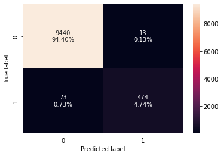

```python
# creating confusion matrix
confusion_matrix_sklearn(xb_tuned, X_val, y_val)
```

### Tuning Xgboost with oversampled data

```python
%%time

# defining model
xb = XGBClassifier(random_state=1,eval_metric="logloss")

# Parameter grid to pass in RandomSearchCV
param_grid={
    'n_estimators': [150, 200, 250],
    'scale_pos_weight': [5,10],
    'learning_rate': [0.1,0.2],
    'gamma': [0,3,5],
    'subsample': [0.8,0.9]
}

#Calling RandomizedSearchCV
xb_tuned_over = RandomizedSearchCV(estimator=xb, param_distributions=param_grid, n_iter=10,
                              n_jobs = -1, scoring=scorer, cv=5, random_state=1)

#Fitting parameters in RandomizedSearchCV
xb_tuned_over.fit(X_train_over,y_train_over)

print("Best parameters are {} with CV score={}:" .format(xb_tuned_over.best_params_,xb_tuned_over.best_score_))
```

```
Best parameters are {'subsample': 0.9, 'scale_pos_weight': 10, 'n_estimators': 200, 'learning_rate': 0.2, 'gamma': 0} with CV score=0.9908034558005822:
Wall time: 27min 24s
```

```python
# Creating new pipeline with best parameters
xb_tuned_over = XGBClassifier(
    subsample=0.9,
    scale_pos_weight=10,
    n_estimators=200,
    learning_rate=0.2,
    gamma=0,
    eval_metric="logloss",
    random_state=1
)

# Fit the model on undersampled training data
xb_tuned_over.fit(X_train_over, y_train_over)
```

```
XGBClassifier(base_score=0.5, booster='gbtree', colsample_bylevel=1,
              colsample_bynode=1, colsample_bytree=1, enable_categorical=False,
              eval_metric='logloss', gamma=0, gpu_id=-1, importance_type=None,
              interaction_constraints='', learning_rate=0.2, max_delta_step=0,
              max_depth=6, min_child_weight=1, missing=nan,
              monotone_constraints='()', n_estimators=200, n_jobs=8,
              num_parallel_tree=1, predictor='auto', random_state=1,
              reg_alpha=0, reg_lambda=1, scale_pos_weight=10, subsample=0.9,
              tree_method='exact', validate_parameters=1, verbosity=None)
```

```python
# Calculating different metrics on train set
xb_grid_train_over = model_performance_classification_sklearn(
    xb_tuned_over, X_train_over, y_train_over
)
print("Training performance:")
xb_grid_train_over
```

```
Training performance:
```

|  | Accuracy | Recall | Precision | F1 |
| --- | --- | --- | --- | --- |
| 0 | 1.00 | 1.00 | 1.00 | 1.00 |

```python
# Calculating different metrics on validation set
xb_grid_val_over = model_performance_classification_sklearn(
    xb_tuned_over, X_val, y_val
)
print("Validation performance:")
xb_grid_val_over
```

```
Validation performance:
```

|  | Accuracy | Recall | Precision | F1 |
| --- | --- | --- | --- | --- |
| 0 | 0.98 | 0.89 | 0.84 | 0.86 |

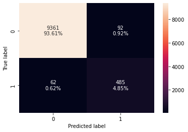

```python
# creating confusion matrix
confusion_matrix_sklearn(xb_tuned_over, X_val, y_val)
```